# DATA 606 Lab 3

(Chapter 3 - Probability)

Donny Lofland

9/14/2019

```r
library(VennDiagram)
library(xtable)
library(formattable)
```

**Dice rolls.** (3.6, p. 92) If you roll a pair of fair dice, what is the probability of

1. getting a sum of 1?

> 0 - the smallest sum you can roll would be 2 (each dice shows a 1)
2. getting a sum of 5?

> To get a sum of five, we need to roll a 4 and 1 or a 2 and 3:

$$P(1)\ and\ P(4)\ or\ \\P(2)\ and\ P(3)]\ or\ \\P(4)\ and\ P(1)\ or\ \\P(3)\ and\ P(2)$$

$$\frac{1}{6} \times \frac{1}{6} + \frac{1}{6} \times \frac{1}{6} + \frac{1}{6} \times \frac{1}{6} + \frac{1}{6} \times \frac{1}{6} = \frac{4}{36} = \frac{1}{9}$$

3. getting a sum of 12?

> The only way to get a sum of 12 is if both dice roll a 6:

$$\frac{1}{6} + \frac{1}{6} = \frac{1}{36}$$

**Poverty and language**. (3.8, p. 93) The American Community Survey is an ongoing survey that provides data every year to give communities the current information they need to plan investments and services. The 2010 American Community Survey estimates that 14.6% of Americans live below the poverty line, 20.7% speak a language other than English (foreign language) at home, and 4.2% fall into both categories.

1. Are living below the poverty line and speaking a foreign language at home disjoint?

> No. Since there is overlap of 4.2%, they are by definition NOT disjoint
2. Draw a Venn diagram summarizing the variables and their associated probabilities.

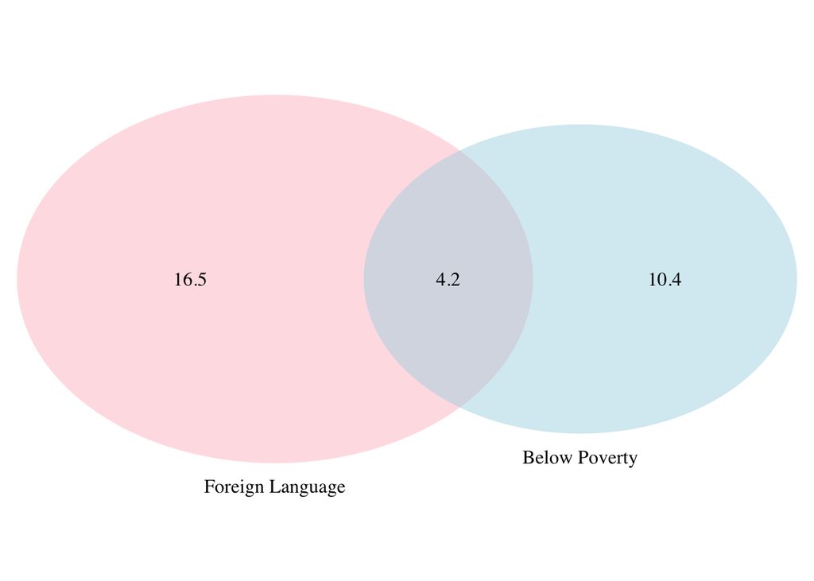

```
## (polygon[GRID.polygon.1], polygon[GRID.polygon.2], polygon[GRID.polygon.3], polygon[GRID.polygon.4], text[GRID.text.5], text[GRID.text.6], text[GRID.text.7], text[GRID.text.8], text[GRID.text.9])
```

```r
grid.newpage()
draw.pairwise.venn(14.6, 20.7, 4.2, category = c("Below Poverty", "Foreign Language"), lty = rep("blank",
    2), fill = c("light blue", "pink"), alpha = rep(0.5, 2), cat.pos = c(0,
    0), cat.dist = rep(0.025, 2))
```

3. What percent of Americans live below the poverty line and only speak English at home?

$$P(Poverty) - P(Poverty\ \textrm{and}\ Foreign) = 14.6 - 4.2 = 10.4\%$$

4. What percent of Americans live below the poverty line or speak a foreign language at home?

$$P(Poverty) + P(Foreign) - P(Poverty\ \textrm{and}\ Foreign) = \\14.6 + 20.7 - 4.2 = 31.1\%$$

5. What percent of Americans live above the poverty line and only speak English at home?

$$P(English\ \textrm{and}\ No Poverty)\\= 100 - P(Povery) + P(Other) - P(Poverty\ \textrm{and}\ Other)\\
= 100-(20.7+14.6-4.2) = 68.9$$

|  | English | Other | *total* |
| --- | --- | --- | --- |
| No Poverty | 68.9 | 16.5 | 85.4 |
| Poverty | 10.4 | 4.2 | 14.6 |
| *total* | 79.3 | 20.7 | 100 |

6. Is the event that someone lives below the poverty line independent of the event that the person speaks a foreign language at home?

1. What is the probability that a randomly chosen male respondent or his partner has blue eyes?

```r
fema_blue <- 108 / 204
male_blue <- 114 / 204
both_blue <- 78 / 204
either_blue <- fema_blue + male_blue - both_blue
```

$$P(f\_blue\ or\ m\_blue) = 70.59% \%$$

2. What is the probability that a randomly chosen male respondent with blue eyes has a partner with blue eyes?

$$P(BlueFemale | BlueMale) = \frac{P(BlueFemale\ and \ BlueMale)}{P(BlueMale)}\\
= \frac{\frac{78}{204}}{\frac{114}{204}}\\
=68.42%\ \%$$

3. What is the probability that a randomly chosen male respondent with brown eyes has a partner with blue eyes? What about the probability of a randomly chosen male respondent with green eyes having a partner with blue eyes?

$$P(BlueFemale | BrownMale) = \frac{P(BlueFemale\ and\ BrownMale)}{P(BrownMale)}\\
= \frac{\frac{19}{204}}{\frac{54}{204}}\\
=35.19%\ \%$$
>

4. Does it appear that the eye colors of male respondents and their partners are independent? Explain your reasoning.

> Portions of Female Eye color given male’s eye color

|  | Blue | Brown | Green |
| --- | --- | --- | --- |
| Blue | 68.42% | 20.18% | 11.40% |
| Brown | 35.19% | 42.59% | 22.22% |
| Green | 30.56% | 25.00% | 44.44% |

> Choices in eye color are clearly dependent … if eye color choice we independent, we’d expect to see similar proportions between the colors. We in fact see that people are more likely to choose a partner with the same eye color as themselves.

1. Find the probability of drawing a hardcover book first then a paperback fiction book second when drawing without replacement.

$$P(Total) = P(H) * P(P)$$

```r
total <- 95
p_H <- 28 / total
total <- total - 1 # Without replacment, we removed 1 book
p_P <- 28 / total
final <- p_H * p_P
```

> The overall probability is 8.78%.
2. Determine the probability of drawing a fiction book first and then a hardcover book second, when drawing without replacement.

$$P(Total) = P(F) * P(H)$$

```r
total <- 95
p_F <- 72 / total
total = total - 1
p_H <- 28 / total

final <- p_F * p_H
```

> The overall probability is 22.58%.
3. Calculate the probability of the scenario in part (b), except this time complete the calculations under the scenario where the first book is placed back on the bookcase before randomly drawing the second book.

$$P(Total) = P(F) * P(H)$$

```r
total <- 95
p_F <- 72 / total
p_H <- 28 / total
final <- p_F * p_H
```

> The overall probability is 22.34%.
4. The final answers to parts (b) and (c) are very similar. Explain why this is the case.

> We have a large sample size of 95 books, so loosing 1 has ~1% impact on the overall total. The book portions mean that that only a fraction of this ~1% was realized between parts (b) and (c)

**Baggage fees**. (3.34, p. 124) An airline charges the following baggage fees: $25 for the first bag and $35 for the second. Suppose 54% of passengers have no checked luggage, 34% have one piece of checked luggage and 12% have two pieces. We suppose a negligible portion of people check more than two bags.

1. Build a probability model, compute the average revenue per passenger, and compute the corresponding standard deviation.

```r
fees <- c(0, 25, 35)
portions <- c(0.54, 0.34, 0.12)
model <- fees * portions

mean(model)
```

```
## [1] 4.233333
```

```r
sd(model)
```

```
## [1] 4.250098
```

2. About how much revenue should the airline expect for a flight of 120 passengers? With what standard deviation? Note any assumptions you make and if you think they are justified.

```r
print(sum(model*120))
```

```
## [1] 1524
```

1. Describe the distribution of total personal income.

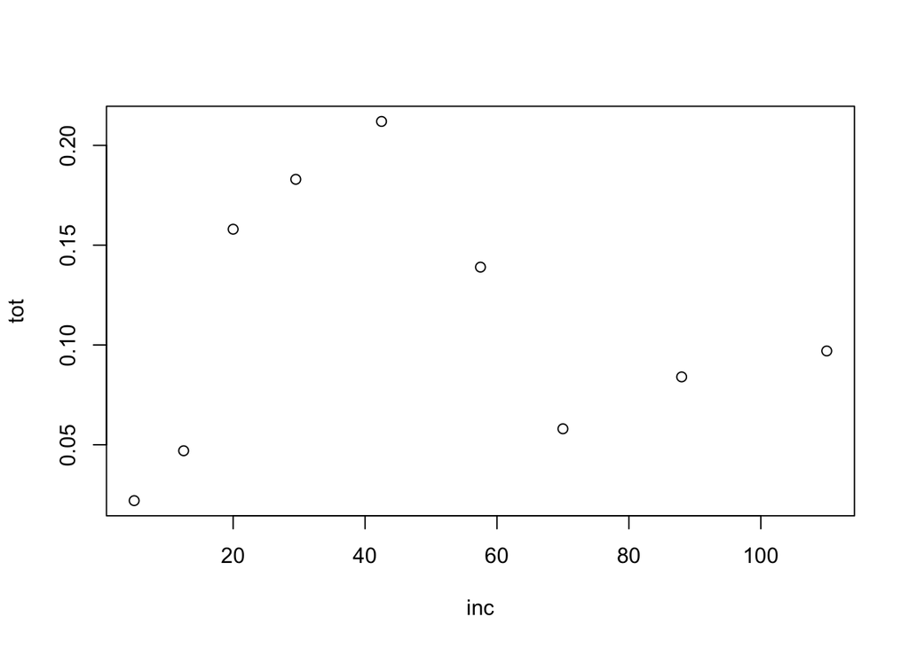

```r
inc <- c(5, 12.5, 20, 29.5, 42.5, 57.5, 70, 88, 110)
tot <- c(0.022, 0.047, 0.158, 0.183, 0.212, 0.139, 0.058, 0.084, 0.097)

plot(inc, tot)
```

```r
sum(tot)       # verify: make sure my tot vector sums to 100% (it should!)
```

```
## [1] 1
```

```r
p_less_than_50 <- sum(tot[0:5])  # sum the first 5 probabilities
p_less_than_50
```

```
## [1] 0.622
```

> The probability is **62.20%**
3. What is the probability that a randomly chosen US resident makes less than $50,000 per year and is female? Note any assumptions you make.

$$P(Total) = P(Less\ than\ 50000) * P(Female)$$

```r
p_F <- sum(tot[0:5]) * 0.41
p_F
```

```
## [1] 0.25502
```

> I’m assuming that income and gender are independent (ha!) … a very poor assumption. My hypothesis is that income and gender are very dependent with more lower income females than males and as a result the probablility of drawning a low income female is probably higher than the **25.50%** calculation.
4. The same data source indicates that 71.8% of females make less than $50,000 per year. Use this value to determine whether or not the assumption you made in part (c) is valid.

> 71.8% is significantly higher than 25.5% which confirm that there is a strong correlation between gender and income. I was correct in assuming that 25.5% was low, but I wouldn’t have guess it was as high as 71%.